```python
import pandas as pd
import numpy as np
import matplotlib.pyplot as plt
import seaborn as sns
import copy
from sklearn.preprocessing import StandardScaler #标准化
from sklearn.model_selection import train_test_split #数据集划分
from sklearn.model_selection import GridSearchCV #网格搜索交叉验证
from sklearn.preprocessing import MinMaxScaler #归一化
from sklearn.linear_model import LinearRegression #正规方程-线性回归
from sklearn.linear_model import SGDRegressor # SGDR梯度下降-线性回归
from sklearn.metrics import mean_squared_error #均方误差MSE
from sklearn.linear_model import Ridge #岭回归(实现了SAG梯度下降)
from sklearn.linear_model import RidgeCV #加交叉验证的岭回归
from sklearn.linear_model import LogisticRegression #逻辑回归
from sklearn.metrics import classification_report #查看精确率，召回率，F1-score
from sklearn.metrics import roc_auc_score #AUC score
from sklearn.metrics import mean_absolute_error #平方绝对误差
from sklearn.metrics import r2_score#R square
from sklearn.neighbors import KNeighborsClassifier #Knn算法
from sklearn.tree import DecisionTreeClassifier,export_graphviz #决策树
from sklearn.preprocessing import MultiLabelBinarizer, OneHotEncoder
from scipy.stats import *
from sklearn.metrics import roc_curve, auc, f1_score
%matplotlib inline
```

# 一.数据探索 & 数据清理

```python
#读取数据
bank = pd.read_csv("E:/期中作业/bank.csv")
bill = pd.read_csv("E:/期中作业/bill.csv")
overdue = pd.read_csv("E:/期中作业/overdue.csv")
userinfo = pd.read_csv("E:/期中作业/userinfo.csv")
```

## 1.观察数据&缺失值处理

```python
bank.head()
```

|  | new_user_id | 交易时间戳 | 交易类型 | 交易金额 | 工资收入标记 | 交易时间 | 交易年 | 交易月 | 交易日 | 交易时 | 交易分 | 交易秒 |
| --- | --- | --- | --- | --- | --- | --- | --- | --- | --- | --- | --- | --- |
| 0 | 65b01fba105ee82613babff7c88929c5 | 58848407247 | 1 | 43.757548 | 0 | 2156-06-25 21:58:44 | 2156 | 6 | 25 | 21 | 58 | 44 |
| 1 | 65b01fba105ee82613babff7c88929c5 | 58849365297 | 1 | 42.143743 | 0 | 2156-06-27 00:35:29 | 2156 | 6 | 27 | 0 | 35 | 29 |
| 2 | 65b01fba105ee82613babff7c88929c5 | 58850118237 | 1 | 40.189051 | 0 | 2156-06-27 21:30:23 | 2156 | 6 | 27 | 21 | 30 | 23 |
| 3 | 65b01fba105ee82613babff7c88929c5 | 58850118447 | 1 | 40.189051 | 0 | 2156-06-27 21:30:44 | 2156 | 6 | 27 | 21 | 30 | 44 |
| 4 | 65b01fba105ee82613babff7c88929c5 | 58850244487 | 1 | 40.189051 | 0 | 2156-06-28 01:00:48 | 2156 | 6 | 28 | 1 | 0 | 48 |

```python
bank.isnull().sum()
```

```
new_user_id    0
交易时间戳          0
交易类型           0
交易金额           0
工资收入标记         0
交易时间           0
交易年            0
交易月            0
交易日            0
交易时            0
交易分            0
交易秒            0
dtype: int64
```

```python
bill.head()
```

|  | new_user_id | 账单时间戳 | 银行id | 上期账单金额 | 上期还款金额 | 信用卡额度 | 本期账单余额 | 本期账单最低还款额 | 消费笔数 | 本期账单金额 | ... | 可用金额 | 预借现金额度 | 还款状态 | 账单时间 | 账单年 | 账单月 | 账单日 | 账单时 | 账单分 | 账单秒 |
| --- | --- | --- | --- | --- | --- | --- | --- | --- | --- | --- | --- | --- | --- | --- | --- | --- | --- | --- | --- | --- | --- |
| 0 | eddcaa8984f8db5199ec28323efb18a4 | 59067443637 | 6 | 50.622246 | 50.657612 | 52.596975 | 50.897707 | 49.846899 | 1 | 26.457513 | ... | 26.457513 | 51.933872 | 0 | 2157-03-06 10:19:23 | 2157 | 3 | 6 | 10 | 19 | 23 |
| 1 | eddcaa8984f8db5199ec28323efb18a4 | 59067444017 | 6 | 50.897707 | 50.901821 | 52.596975 | 51.101179 | 49.911428 | 1 | 26.457513 | ... | 26.457513 | 51.933872 | 0 | 2157-03-06 10:20:01 | 2157 | 3 | 6 | 10 | 20 | 1 |
| 2 | eddcaa8984f8db5199ec28323efb18a4 | 59067444277 | 6 | 51.101179 | 51.137354 | 52.596975 | 51.283715 | 49.977605 | 1 | 26.457513 | ... | 26.457513 | 51.933872 | 0 | 2157-03-06 10:20:27 | 2157 | 3 | 6 | 10 | 20 | 27 |
| 3 | eddcaa8984f8db5199ec28323efb18a4 | 59067445157 | 6 | 51.283715 | 51.283799 | 52.915867 | 52.252502 | 50.474921 | 1 | 26.457513 | ... | 26.457513 | 52.256811 | 0 | 2157-03-06 10:21:55 | 2157 | 3 | 6 | 10 | 21 | 55 |
| 4 | eddcaa8984f8db5199ec28323efb18a4 | 59067445627 | 6 | 52.252502 | 52.256812 | 52.915867 | 52.304048 | 50.508400 | 1 | 26.457513 | ... | 26.457513 | 52.256811 | 0 | 2157-03-06 10:22:42 | 2157 | 3 | 6 | 10 | 22 | 42 |

5 rows × 22 columns

```python
bill.isnull().sum()
```

```
new_user_id    0
账单时间戳          0
银行id           0
上期账单金额         0
上期还款金额         0
信用卡额度          0
本期账单余额         0
本期账单最低还款额      0
消费笔数           0
本期账单金额         0
调整金额           0
循环利息           0
可用金额           0
预借现金额度         0
还款状态           0
账单时间           0
账单年            0
账单月            0
账单日            0
账单时            0
账单分            0
账单秒            0
dtype: int64
```

```python
overdue.head()
```

|  | new_user_id | 标签 | 分数 |
| --- | --- | --- | --- |
| 0 | eddcaa8984f8db5199ec28323efb18a4 | 0 | 80.619639 |
| 1 | 65b01fba105ee82613babff7c88929c5 | 1 | 53.052357 |
| 2 | 968083a2d1a7e6b5b85a66b0bc412830 | 1 | 46.796518 |
| 3 | 18aeed58fd39a58cc1430a3a417ed7a9 | 1 | 82.354501 |
| 4 | bae4896cea4a34616ae3babca11439ae | 1 | 83.758928 |

```python
overdue.isnull().sum()
```

```
new_user_id    0
标签             0
分数             0
dtype: int64
```

```python
userinfo.head()
```

|  | new_user_id | 性别 | 职业 | 教育程度 | 婚姻状态 | 户口类型 |
| --- | --- | --- | --- | --- | --- | --- |
| 0 | 7259fe272934e0dc348092c37544a445 | 女 | 公职 | 本科及以上 | 未婚 | 集体户口 |
| 1 | 0c87f6b1f7e0350a35841ba34df9d26a | 男 | 公职 | 本科及以上 | 离异 | 集体户口 |
| 2 | 74c53a62f15cc039864aefc41170f81b | 男 | 公职 | 大专 | 离异 | 家庭户口 |
| 3 | 211f56f356fa6ecc6334bb73e52c7b16 | 男 | 企业 | 高中 | 离异 | 农业户口 |
| 4 | 07b0d9ac7924424894141b2fecfa0ee0 | 男 | 公职 | 本科及以上 | 已婚 | 集体户口 |

```python
userinfo.isnull().sum()
```

```
new_user_id    0
性别             0
职业             2
教育程度           0
婚姻状态           1
户口类型           0
dtype: int64
```

```python
#删除userinfo仅有的三条具有缺失值的样本
userinfo.dropna(inplace=True)
```

```python
userinfo.isnull().sum()
```

```
new_user_id    0
性别             0
职业             0
教育程度           0
婚姻状态           0
户口类型           0
dtype: int64
```

## 2.单特征统计

### 查看交易金额,本期账单金额,工资的平均数，中位数，标准差，方差。 并绘图。

```python
#交易金额
bank['交易金额'].aggregate(func=['mean','median','std','var'])
```

```
mean      43.415927
median    43.757548
std        3.052264
var        9.316314
Name: 交易金额, dtype: float64
```

```python
#本期账单金额
bill['本期账单金额'].aggregate(func=['mean','median','std','var'])
```

```
mean       42.847388
median     50.197147
std        11.949352
var       142.787014
Name: 本期账单金额, dtype: float64
```

```python
#工资
wage = bank.loc[bank['工资收入标记']==1,'交易金额']
wage.name = '工资'
```

```python
wage.head()
```

```
950    47.070770
952    46.203056
957    46.554156
962    47.046780
964    46.116645
Name: 工资, dtype: float64
```

```python
wage.aggregate(func=['mean','median','std','var'])
```

```
mean      45.036488
median    46.030944
std        2.692801
var        7.251175
Name: 工资, dtype: float64
```

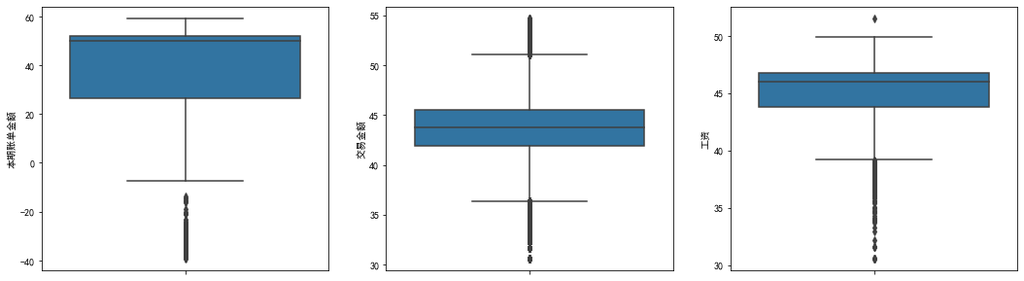

```python
#绘制箱型图
plt.rcParams['font.sans-serif'] = ['SimHei'] # 指定默认字体
plt.rcParams['axes.unicode_minus'] = False
fig,ax = plt.subplots(nrows=1,ncols=3,figsize=(18,5))

sns.boxplot(y=bill['本期账单金额'],ax=ax[0])
sns.boxplot(y=bank['交易金额'],ax=ax[1])
sns.boxplot(y=wage,ax=ax[2])
```

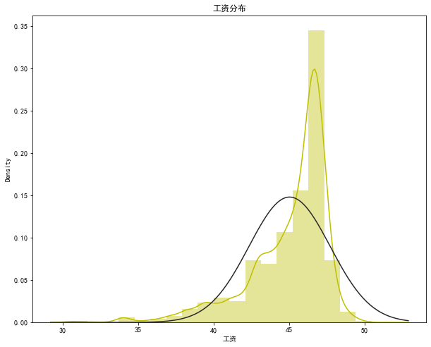

```python
#绘制工资的频数分布图
plt.rcParams['font.sans-serif'] = ['SimHei'] # 指定默认字体
plt.rcParams['axes.unicode_minus'] = False
fig,ax = plt.subplots(figsize=(10,8))
ax.set(xlabel='工资')
ax.set(title='工资分布')
sns.distplot(wage,color='y',fit=norm,bins=20)
```

## 2.相关性统计

### ① 逾期 与{性别，职业，教育程度，婚姻状态，户口类型}——散点气泡图

### ② 分数 与{性别，职业，教育程度，婚姻状态，户口类型}——散点图

### ③ 逾期 ，分数，性别，职业，教育程度，婚姻状态，户口类型——热力图

### 编码如下：

[figure not shown]

```python
#为了绘制气泡图，要先将非数值类型编码
def strTOnum(col):
    res = {}
    mark = 0
    for name in userinfo[col].unique():
        res[name] = mark
        mark+=1
    return res
```

```python
#编码
dic1,dic2,dic3,dic4,dic5 = strTOnum('性别'),strTOnum('职业'),strTOnum('教育程度'),strTOnum('户口类型'),strTOnum('婚姻状态')
new_userinfo = userinfo.replace({'性别':dic1,'职业':dic2,'教育程度':dic3,'户口类型':dic4,'婚姻状态':dic5})
new_userinfo.head()
```

|  | new_user_id | 性别 | 职业 | 教育程度 | 婚姻状态 | 户口类型 |
| --- | --- | --- | --- | --- | --- | --- |
| 0 | 7259fe272934e0dc348092c37544a445 | 0 | 0 | 0 | 0 | 0 |
| 1 | 0c87f6b1f7e0350a35841ba34df9d26a | 1 | 0 | 0 | 1 | 0 |
| 2 | 74c53a62f15cc039864aefc41170f81b | 1 | 0 | 1 | 1 | 1 |
| 3 | 211f56f356fa6ecc6334bb73e52c7b16 | 1 | 1 | 2 | 1 | 2 |
| 4 | 07b0d9ac7924424894141b2fecfa0ee0 | 1 | 0 | 0 | 2 | 0 |

```python
#连接overdue，为查看相关性做准备
tab1 = pd.merge(overdue,new_userinfo,on='new_user_id')
tab1.rename(columns={'标签':'逾期'},inplace=True)
tab1.head()
```

|  | new_user_id | 逾期 | 分数 | 性别 | 职业 | 教育程度 | 婚姻状态 | 户口类型 |
| --- | --- | --- | --- | --- | --- | --- | --- | --- |
| 0 | eddcaa8984f8db5199ec28323efb18a4 | 0 | 80.619639 | 1 | 0 | 0 | 1 | 2 |
| 1 | 65b01fba105ee82613babff7c88929c5 | 1 | 53.052357 | 1 | 2 | 0 | 0 | 1 |
| 2 | 968083a2d1a7e6b5b85a66b0bc412830 | 1 | 46.796518 | 1 | 0 | 2 | 0 | 0 |
| 3 | 18aeed58fd39a58cc1430a3a417ed7a9 | 1 | 82.354501 | 1 | 1 | 0 | 0 | 0 |
| 4 | bae4896cea4a34616ae3babca11439ae | 1 | 83.758928 | 1 | 2 | 0 | 0 | 0 |

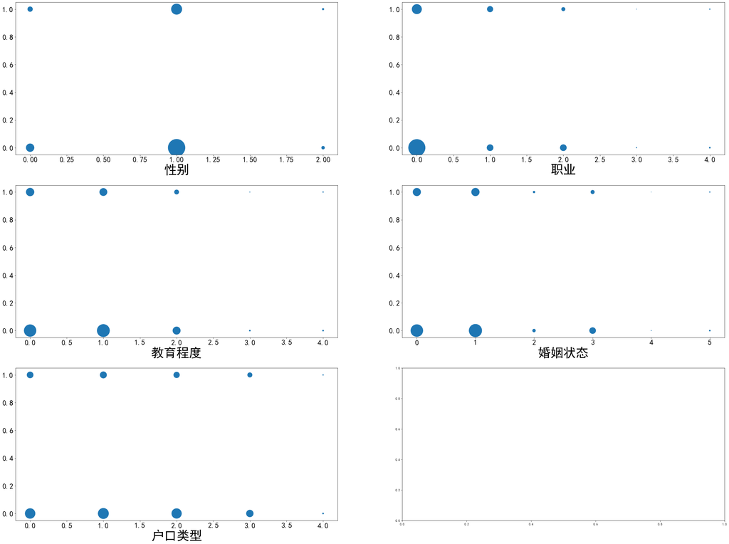

```python
#对'逾期'绘制散点气泡图
fig,ax = plt.subplots(3,2,figsize=(40,30))
sex_label = tab1.groupby(['性别','逾期']).count()['new_user_id'].reset_index()
work_label = tab1.groupby(['职业','逾期']).count()['new_user_id'].reset_index()
edu_label = tab1.groupby(['教育程度','逾期']).count()['new_user_id'].reset_index()
marry_label = tab1.groupby(['婚姻状态','逾期']).count()['new_user_id'].reset_index()
house_label = tab1.groupby(['户口类型','逾期']).count()['new_user_id'].reset_index()
ax[0,0].scatter(sex_label['性别'],sex_label['逾期'],sex_label['new_user_id']/2)
ax[0,0].set_xlabel("性别",fontsize=40)
ax[0,0].tick_params(labelsize=23)

ax[0,1].scatter(work_label['职业'],work_label['逾期'],work_label['new_user_id']/2)
ax[0,1].set_xlabel("职业",fontsize=40)
ax[0,1].tick_params(labelsize=23)

ax[1,0].scatter(edu_label['教育程度'],edu_label['逾期'],edu_label['new_user_id']/2)
ax[1,0].set_xlabel("教育程度",fontsize=40)
ax[1,0].tick_params(labelsize=23)

ax[1,1].scatter(marry_label['婚姻状态'],marry_label['逾期'],marry_label['new_user_id']/2)
ax[1,1].set_xlabel("婚姻状态",fontsize=40)
ax[1,1].tick_params(labelsize=23)

ax[2,0].scatter(house_label['户口类型'],house_label['逾期'],house_label['new_user_id']/2)
ax[2,0].set_xlabel("户口类型",fontsize=40)
ax[2,0].tick_params(labelsize=23)
```

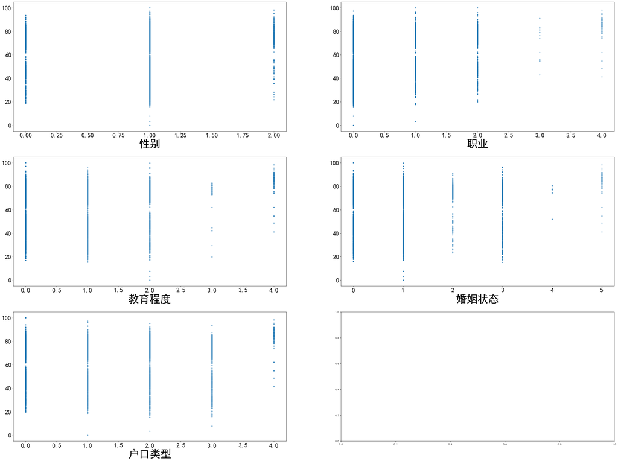

```python
#对'分数'绘制散点图
fig,ax = plt.subplots(3,2,figsize=(40,30))
ax[0,0].scatter(tab1['性别'],tab1['分数'],10)
ax[0,0].set_xlabel("性别",fontsize=40)
ax[0,0].tick_params(labelsize=23)

ax[0,1].scatter(tab1['职业'],tab1['分数'],10)
ax[0,1].set_xlabel("职业",fontsize=40)
ax[0,1].tick_params(labelsize=23)

ax[1,0].scatter(tab1['教育程度'],tab1['分数'],10)
ax[1,0].set_xlabel("教育程度",fontsize=40)
ax[1,0].tick_params(labelsize=23)

ax[1,1].scatter(tab1['婚姻状态'],tab1['分数'],10)
ax[1,1].set_xlabel("婚姻状态",fontsize=40)
ax[1,1].tick_params(labelsize=23)

ax[2,0].scatter(tab1['户口类型'],tab1['分数'],10)
ax[2,0].set_xlabel("户口类型",fontsize=40)
ax[2,0].tick_params(labelsize=23)
```

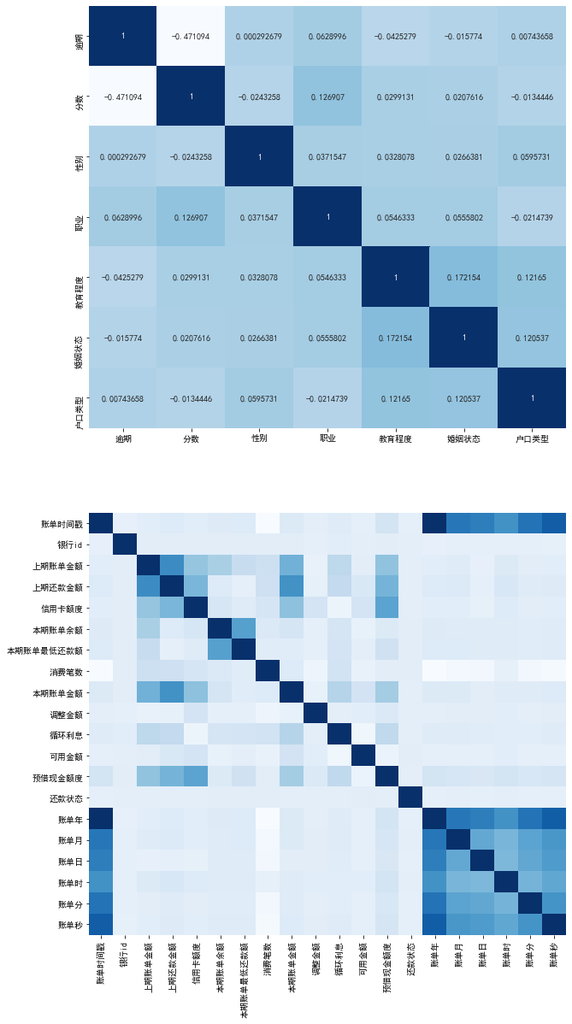

```python
#热力图
corr1 = tab1.corr()
fig,ax = plt.subplots(2,1,figsize=(10,20))
h=sns.heatmap(corr1,fmt='g', cmap='Blues',annot=True,cbar=False,ax = ax[0]) #画热力图，设置cbar=Falese
# cb.ax.tick_params(labelsize=10) #设置colorbar刻度字体大小。
corr2 = bill.corr()
sns.heatmap(corr2,fmt='g', cmap='Blues',annot=False,cbar=False,ax = ax[1]) #画热力图，设置cbar=Falese
```

# 二. 数据预处理 | 特征工程

## 1.将userinfo进行独热编码处理

```python
userinfo.head()
```

|  | new_user_id | 性别 | 职业 | 教育程度 | 婚姻状态 | 户口类型 |
| --- | --- | --- | --- | --- | --- | --- |
| 0 | 7259fe272934e0dc348092c37544a445 | 女 | 公职 | 本科及以上 | 未婚 | 集体户口 |
| 1 | 0c87f6b1f7e0350a35841ba34df9d26a | 男 | 公职 | 本科及以上 | 离异 | 集体户口 |
| 2 | 74c53a62f15cc039864aefc41170f81b | 男 | 公职 | 大专 | 离异 | 家庭户口 |
| 3 | 211f56f356fa6ecc6334bb73e52c7b16 | 男 | 企业 | 高中 | 离异 | 农业户口 |
| 4 | 07b0d9ac7924424894141b2fecfa0ee0 | 男 | 公职 | 本科及以上 | 已婚 | 集体户口 |

```python
hot_userinfo = pd.get_dummies(userinfo, columns=["性别", "职业", "教育程度", "婚姻状态", "户口类型"])
```

```python
hot_userinfo.head()
```

|  | new_user_id | 性别_女 | 性别_未知 | 性别_男 | 职业_事业单位 | 职业_企业 | 职业_公职 | 职业_学生 | 职业_无业 | 教育程度_初中及以下 | ... | 婚姻状态_其他情况 | 婚姻状态_已婚 | 婚姻状态_未婚 | 婚姻状态_未知 | 婚姻状态_离异 | 户口类型_其他户口 | 户口类型_农业户口 | 户口类型_家庭户口 | 户口类型_未知 | 户口类型_集体户口 |
| --- | --- | --- | --- | --- | --- | --- | --- | --- | --- | --- | --- | --- | --- | --- | --- | --- | --- | --- | --- | --- | --- |
| 0 | 7259fe272934e0dc348092c37544a445 | 1 | 0 | 0 | 0 | 0 | 1 | 0 | 0 | 0 | ... | 0 | 0 | 1 | 0 | 0 | 0 | 0 | 0 | 0 | 1 |
| 1 | 0c87f6b1f7e0350a35841ba34df9d26a | 0 | 0 | 1 | 0 | 0 | 1 | 0 | 0 | 0 | ... | 0 | 0 | 0 | 0 | 1 | 0 | 0 | 0 | 0 | 1 |
| 2 | 74c53a62f15cc039864aefc41170f81b | 0 | 0 | 1 | 0 | 0 | 1 | 0 | 0 | 0 | ... | 0 | 0 | 0 | 0 | 1 | 0 | 0 | 1 | 0 | 0 |
| 3 | 211f56f356fa6ecc6334bb73e52c7b16 | 0 | 0 | 1 | 0 | 1 | 0 | 0 | 0 | 0 | ... | 0 | 0 | 0 | 0 | 1 | 0 | 1 | 0 | 0 | 0 |
| 4 | 07b0d9ac7924424894141b2fecfa0ee0 | 0 | 0 | 1 | 0 | 0 | 1 | 0 | 0 | 0 | ... | 0 | 1 | 0 | 0 | 0 | 0 | 0 | 0 | 0 | 1 |

5 rows × 25 columns

## 2.特征生成

### 参考：

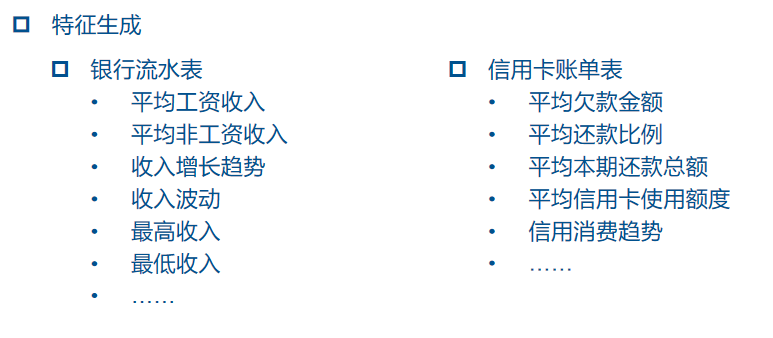

```python
#建一个特征表用来连接所有待添加的特征，为模型训练做准备  目标值：逾期，分数
feature = copy.deepcopy(overdue)
```

```python
feature.rename(columns={'标签':'逾期'},inplace=True)
feature.head()
```

|  | new_user_id | 逾期 | 分数 |
| --- | --- | --- | --- |
| 0 | eddcaa8984f8db5199ec28323efb18a4 | 0 | 80.619639 |
| 1 | 65b01fba105ee82613babff7c88929c5 | 1 | 53.052357 |
| 2 | 968083a2d1a7e6b5b85a66b0bc412830 | 1 | 46.796518 |
| 3 | 18aeed58fd39a58cc1430a3a417ed7a9 | 1 | 82.354501 |
| 4 | bae4896cea4a34616ae3babca11439ae | 1 | 83.758928 |

### 2.1 添加：状态性特征

```python
#求平均工资收入与非工资收入:
#将bank表按user_id分组，统计工资收入标记为1的平均交易金额即可
bank_mark1 = bank.loc[bank['工资收入标记']==1,:]
bank_mark0 = bank.loc[(bank['工资收入标记']==0)&(bank['交易类型']==0),:]

feat_avg_wage = bank_mark1.groupby(['new_user_id'])['交易金额'].agg(func=['mean'])
feat_avg_wage.reset_index(inplace=True)
feat_avg_wage.rename(columns = {'mean':'平均工资收入'},inplace=True)

feat_avg_Nwage = bank_mark0.groupby(['new_user_id'])['交易金额'].agg(func=['mean'])
feat_avg_Nwage.reset_index(inplace=True)
feat_avg_Nwage.rename(columns = {'mean':'平均非工资收入'},inplace=True)
```

```python
#将平均工资和平均非工资收入特征连接到feature并用 (平均值or0?  发现是0比较好) 填补空缺
feature = pd.merge(feature,feat_avg_wage,on='new_user_id',how='left')
feature = pd.merge(feature,feat_avg_Nwage,on='new_user_id',how='left')
#feature['平均工资收入'].fillna(feat_avg_wage['平均工资收入'].mean(),inplace=True)
#feature['平均非工资收入'].fillna(feat_avg_Nwage['平均非工资收入'].mean(),inplace=True)
feature['平均工资收入'].fillna(0,inplace=True)
feature['平均非工资收入'].fillna(0,inplace=True)
print("特征添加成功:\n")
feature.head()
```

```
特征添加成功:
```

|  | new_user_id | 逾期 | 分数 | 平均工资收入 | 平均非工资收入 |
| --- | --- | --- | --- | --- | --- |
| 0 | eddcaa8984f8db5199ec28323efb18a4 | 0 | 80.619639 | 0.0 | 0.000000 |
| 1 | 65b01fba105ee82613babff7c88929c5 | 1 | 53.052357 | 0.0 | 45.383917 |
| 2 | 968083a2d1a7e6b5b85a66b0bc412830 | 1 | 46.796518 | 0.0 | 43.917113 |
| 3 | 18aeed58fd39a58cc1430a3a417ed7a9 | 1 | 82.354501 | 0.0 | 0.000000 |
| 4 | bae4896cea4a34616ae3babca11439ae | 1 | 83.758928 | 0.0 | 0.000000 |

```python
#求最高收入与最低收入:
feat_max_wage = bank_mark1.groupby(['new_user_id'])['交易金额'].agg(func=['max']).reset_index()
feat_max_wage.rename(columns = {'max':'最大工资收入'},inplace=True)
feat_min_wage = bank_mark1.groupby(['new_user_id'])['交易金额'].agg(func=['min']).reset_index()
feat_min_wage.rename(columns = {'min':'最低工资收入'},inplace=True)
```

```python
#将最高收入、最低收入特征连接到feature并用  (平均值or0?) 填补空缺
feature = pd.merge(feature,feat_max_wage,on='new_user_id',how='left')
feature = pd.merge(feature,feat_min_wage,on='new_user_id',how='left')
# feature['最大工资收入'].fillna(feat_max_wage['最大工资收入'].mean(),inplace=True)
# feature['最低工资收入'].fillna(feat_min_wage['最低工资收入'].mean(),inplace=True)
feature['最大工资收入'].fillna(0,inplace=True)
feature['最低工资收入'].fillna(0,inplace=True)
print("特征添加成功:\n")
feature.head()
```

```
特征添加成功:
```

|  | new_user_id | 逾期 | 分数 | 平均工资收入 | 平均非工资收入 | 最大工资收入 | 最低工资收入 |
| --- | --- | --- | --- | --- | --- | --- | --- |
| 0 | eddcaa8984f8db5199ec28323efb18a4 | 0 | 80.619639 | 0.0 | 0.000000 | 0.0 | 0.0 |
| 1 | 65b01fba105ee82613babff7c88929c5 | 1 | 53.052357 | 0.0 | 45.383917 | 0.0 | 0.0 |
| 2 | 968083a2d1a7e6b5b85a66b0bc412830 | 1 | 46.796518 | 0.0 | 43.917113 | 0.0 | 0.0 |
| 3 | 18aeed58fd39a58cc1430a3a417ed7a9 | 1 | 82.354501 | 0.0 | 0.000000 | 0.0 | 0.0 |
| 4 | bae4896cea4a34616ae3babca11439ae | 1 | 83.758928 | 0.0 | 0.000000 | 0.0 | 0.0 |

```python
#求最高非工资收入与最低非工资收入
feat_max_Nwage = bank_mark0.groupby(['new_user_id'])['交易金额'].agg(func=['max']).reset_index()
feat_max_Nwage.rename(columns = {'max':'最大非工资收入'},inplace=True)
feat_min_Nwage = bank_mark0.groupby(['new_user_id'])['交易金额'].agg(func=['min']).reset_index()
feat_min_Nwage.rename(columns = {'min':'最低非工资收入'},inplace=True)
#连接到feature并用  (平均值or0?) 填补空缺
feature = pd.merge(feature,feat_max_Nwage,on='new_user_id',how='left')
feature = pd.merge(feature,feat_min_Nwage,on='new_user_id',how='left')
# feature['最大非工资收入'].fillna(feat_max_Nwage['最大非工资收入'].mean(),inplace=True)
# feature['最低非工资收入'].fillna(feat_min_Nwage['最低非工资收入'].mean(),inplace=True)
feature['最大非工资收入'].fillna(0,inplace=True)
feature['最低非工资收入'].fillna(0,inplace=True)
```

```python
print("特征添加成功:\n")
feature.head()
```

```
特征添加成功:
```

|  | new_user_id | 逾期 | 分数 | 平均工资收入 | 平均非工资收入 | 最大工资收入 | 最低工资收入 | 最大非工资收入 | 最低非工资收入 |
| --- | --- | --- | --- | --- | --- | --- | --- | --- | --- |
| 0 | eddcaa8984f8db5199ec28323efb18a4 | 0 | 80.619639 | 0.0 | 0.000000 | 0.0 | 0.0 | 0.000000 | 0.000000 |
| 1 | 65b01fba105ee82613babff7c88929c5 | 1 | 53.052357 | 0.0 | 45.383917 | 0.0 | 0.0 | 49.672511 | 30.568844 |
| 2 | 968083a2d1a7e6b5b85a66b0bc412830 | 1 | 46.796518 | 0.0 | 43.917113 | 0.0 | 0.0 | 48.209510 | 35.416795 |
| 3 | 18aeed58fd39a58cc1430a3a417ed7a9 | 1 | 82.354501 | 0.0 | 0.000000 | 0.0 | 0.0 | 0.000000 | 0.000000 |
| 4 | bae4896cea4a34616ae3babca11439ae | 1 | 83.758928 | 0.0 | 0.000000 | 0.0 | 0.0 | 0.000000 | 0.000000 |

```python
#求最大欠款金额和平均还款比例并连接到feature，填补空缺
bill['欠款金额'] = bill['上期账单金额'] - bill['上期还款金额']
bill['还款比例'] = bill['上期账单金额']/bill['上期还款金额']
feat_max_qian = bill.groupby(['new_user_id'])['欠款金额'].agg(func=['max']).reset_index()
feat_max_qian.rename(columns = {'max':'最大欠款金额'},inplace = True)
feat_avg_huan = bill.groupby(['new_user_id'])['还款比例'].agg(func=['mean']).reset_index()
feat_avg_huan.rename(columns = {'mean':'平均还款比例'},inplace = True)
feature = pd.merge(feature,feat_max_qian,on = 'new_user_id',how = 'left')
feature = pd.merge(feature,feat_avg_huan,on = 'new_user_id',how = 'left')
feature['最大欠款金额'].fillna(0,inplace = True)
feature['平均还款比例'].fillna(0,inplace =True)
print("特征添加成功:\n")
feature.head()
```

```
特征添加成功:
```

|  | new_user_id | 逾期 | 分数 | 平均工资收入 | 平均非工资收入 | 最大工资收入 | 最低工资收入 | 最大非工资收入 | 最低非工资收入 | 最大欠款金额 | 平均还款比例 |
| --- | --- | --- | --- | --- | --- | --- | --- | --- | --- | --- | --- |
| 0 | eddcaa8984f8db5199ec28323efb18a4 | 0 | 80.619639 | 0.0 | 0.000000 | 0.0 | 0.0 | 0.000000 | 0.000000 | 1.516167 | 0.960151 |
| 1 | 65b01fba105ee82613babff7c88929c5 | 1 | 53.052357 | 0.0 | 45.383917 | 0.0 | 0.0 | 49.672511 | 30.568844 | 62.891473 | 0.853864 |
| 2 | 968083a2d1a7e6b5b85a66b0bc412830 | 1 | 46.796518 | 0.0 | 43.917113 | 0.0 | 0.0 | 48.209510 | 35.416795 | 26.003022 | 0.976416 |
| 3 | 18aeed58fd39a58cc1430a3a417ed7a9 | 1 | 82.354501 | 0.0 | 0.000000 | 0.0 | 0.0 | 0.000000 | 0.000000 | 2.374990 | 0.994188 |
| 4 | bae4896cea4a34616ae3babca11439ae | 1 | 83.758928 | 0.0 | 0.000000 | 0.0 | 0.0 | 0.000000 | 0.000000 | -47.870395 | -0.809331 |

### 状态性特征添加完成

```python
def showRed(val):
    return 'background-color:red'

feat2 = ['平均工资收入','平均非工资收入','最大工资收入','最低工资收入','最大非工资收入','最低非工资收入','最大欠款金额','平均还款比例']
showFeature = feature.loc[:5,:]
showFeature.style.applymap(showRed,subset=pd.IndexSlice[:,feat2])
```

|  | new_user_id | 逾期 | 分数 | 平均工资收入 | 平均非工资收入 | 最大工资收入 | 最低工资收入 | 最大非工资收入 | 最低非工资收入 | 最大欠款金额 | 平均还款比例 |
| --- | --- | --- | --- | --- | --- | --- | --- | --- | --- | --- | --- |
| 0 | eddcaa8984f8db5199ec28323efb18a4 | 0 | 80.619639 | 0.000000 | 0.000000 | 0.000000 | 0.000000 | 0.000000 | 0.000000 | 1.516167 | 0.960151 |
| 1 | 65b01fba105ee82613babff7c88929c5 | 1 | 53.052357 | 0.000000 | 45.383917 | 0.000000 | 0.000000 | 49.672511 | 30.568844 | 62.891473 | 0.853864 |
| 2 | 968083a2d1a7e6b5b85a66b0bc412830 | 1 | 46.796518 | 0.000000 | 43.917113 | 0.000000 | 0.000000 | 48.209510 | 35.416795 | 26.003022 | 0.976416 |
| 3 | 18aeed58fd39a58cc1430a3a417ed7a9 | 1 | 82.354501 | 0.000000 | 0.000000 | 0.000000 | 0.000000 | 0.000000 | 0.000000 | 2.374990 | 0.994188 |
| 4 | bae4896cea4a34616ae3babca11439ae | 1 | 83.758928 | 0.000000 | 0.000000 | 0.000000 | 0.000000 | 0.000000 | 0.000000 | -47.870395 | -0.809331 |
| 5 | f55a25c9dfa9755e9bc1d3cfe757db58 | 0 | 75.795550 | 0.000000 | 0.000000 | 0.000000 | 0.000000 | 0.000000 | 0.000000 | 1.782888 | 1.025947 |

### 2.2 添加：趋势性特征

```python
feature.head()
```

|  | new_user_id | 逾期 | 分数 | 平均工资收入 | 平均非工资收入 | 最大工资收入 | 最低工资收入 | 最大非工资收入 | 最低非工资收入 | 最大欠款金额 | 平均还款比例 |
| --- | --- | --- | --- | --- | --- | --- | --- | --- | --- | --- | --- |
| 0 | eddcaa8984f8db5199ec28323efb18a4 | 0 | 80.619639 | 0.0 | 0.000000 | 0.0 | 0.0 | 0.000000 | 0.000000 | 1.516167 | 0.960151 |
| 1 | 65b01fba105ee82613babff7c88929c5 | 1 | 53.052357 | 0.0 | 45.383917 | 0.0 | 0.0 | 49.672511 | 30.568844 | 62.891473 | 0.853864 |
| 2 | 968083a2d1a7e6b5b85a66b0bc412830 | 1 | 46.796518 | 0.0 | 43.917113 | 0.0 | 0.0 | 48.209510 | 35.416795 | 26.003022 | 0.976416 |
| 3 | 18aeed58fd39a58cc1430a3a417ed7a9 | 1 | 82.354501 | 0.0 | 0.000000 | 0.0 | 0.0 | 0.000000 | 0.000000 | 2.374990 | 0.994188 |
| 4 | bae4896cea4a34616ae3babca11439ae | 1 | 83.758928 | 0.0 | 0.000000 | 0.0 | 0.0 | 0.000000 | 0.000000 | -47.870395 | -0.809331 |

```python
#构造：2156~2157年平均工资增长趋势，若增长则为1，否则为0：
cond1 = (bank['交易年']==2156)&(bank['工资收入标记']==1)
cond2 = (bank['交易年']==2157)&(bank['工资收入标记']==1)
bank_2156_wage = bank.loc[cond1,:]
bank_2157_wage = bank.loc[cond2,:]
#分组，取工资平均数
feat_2156_wage = bank_2156_wage.groupby('new_user_id')['交易金额'].agg(['mean']).reset_index()
feat_2157_wage = bank_2157_wage.groupby('new_user_id')['交易金额'].agg(['mean']).reset_index()
feat_2156_wage = pd.merge(feature['new_user_id'],feat_2156_wage,how = 'left',on = 'new_user_id')
feat_2157_wage = pd.merge(feature['new_user_id'],feat_2157_wage,how = 'left',on = 'new_user_id')
feat_2156_wage.fillna(0,inplace=True)
feat_2157_wage.fillna(0,inplace=True)
feat_year_wage = pd.merge(feat_2156_wage,feat_2157_wage,on='new_user_id')
feat_year_wage.rename(columns={'mean_x':'2156年平均工资','mean_y':'2157年平均工资'},inplace=True)
feat_year_wage['年工资增长趋势'] = 0
cond = feat_year_wage['2156年平均工资']<feat_year_wage['2157年平均工资']
feat_year_wage.loc[cond,'年工资增长趋势'] = 1
feat_year_tend = feat_year_wage.loc[:,['new_user_id','年工资增长趋势']]
feature = pd.merge(feature,feat_year_tend,on ='new_user_id',how = 'left')
print("特征添加成功:\n")
feature.head()
```

```
特征添加成功:
```

|  | new_user_id | 逾期 | 分数 | 平均工资收入 | 平均非工资收入 | 最大工资收入 | 最低工资收入 | 最大非工资收入 | 最低非工资收入 | 最大欠款金额 | 平均还款比例 | 年工资增长趋势 |
| --- | --- | --- | --- | --- | --- | --- | --- | --- | --- | --- | --- | --- |
| 0 | eddcaa8984f8db5199ec28323efb18a4 | 0 | 80.619639 | 0.0 | 0.000000 | 0.0 | 0.0 | 0.000000 | 0.000000 | 1.516167 | 0.960151 | 0 |
| 1 | 65b01fba105ee82613babff7c88929c5 | 1 | 53.052357 | 0.0 | 45.383917 | 0.0 | 0.0 | 49.672511 | 30.568844 | 62.891473 | 0.853864 | 0 |
| 2 | 968083a2d1a7e6b5b85a66b0bc412830 | 1 | 46.796518 | 0.0 | 43.917113 | 0.0 | 0.0 | 48.209510 | 35.416795 | 26.003022 | 0.976416 | 0 |
| 3 | 18aeed58fd39a58cc1430a3a417ed7a9 | 1 | 82.354501 | 0.0 | 0.000000 | 0.0 | 0.0 | 0.000000 | 0.000000 | 2.374990 | 0.994188 | 0 |
| 4 | bae4896cea4a34616ae3babca11439ae | 1 | 83.758928 | 0.0 | 0.000000 | 0.0 | 0.0 | 0.000000 | 0.000000 | -47.870395 | -0.809331 | 0 |

```python
#构造：2156~2157年非工资收入增长趋势，若增长则为1，否则为0：
cond1 = (bank['交易年']==2156)&(bank['工资收入标记']==0)&(bank['交易类型']==0)
cond2 = (bank['交易年']==2157)&(bank['工资收入标记']==0)&(bank['交易类型']==0)
bank_2156_Nwage = bank.loc[cond1,:]
bank_2157_Nwage = bank.loc[cond2,:]
#分组，取工资平均数
feat_2156_Nwage = bank_2156_Nwage.groupby('new_user_id')['交易金额'].agg(['mean']).reset_index()
feat_2157_Nwage = bank_2157_Nwage.groupby('new_user_id')['交易金额'].agg(['mean']).reset_index()
feat_2156_Nwage = pd.merge(feature['new_user_id'],feat_2156_Nwage,how = 'left',on = 'new_user_id')
feat_2157_Nwage = pd.merge(feature['new_user_id'],feat_2157_Nwage,how = 'left',on = 'new_user_id')
feat_2156_Nwage.fillna(0,inplace=True)
feat_2157_Nwage.fillna(0,inplace=True)
feat_year_Nwage = pd.merge(feat_2156_Nwage,feat_2157_Nwage,on='new_user_id')
feat_year_Nwage.rename(columns={'mean_x':'2156年非工资收入','mean_y':'2157年非工资收入'},inplace=True)
feat_year_Nwage['年非工资增长趋势'] = 0
cond = feat_year_Nwage['2156年非工资收入']<feat_year_Nwage['2157年非工资收入']
feat_year_Nwage.loc[cond,'年非工资增长趋势'] = 1
feat_year_Ntend = feat_year_Nwage.loc[:,['new_user_id','年非工资增长趋势']]
feature = pd.merge(feature,feat_year_Ntend,on ='new_user_id',how = 'left')
print("特征添加成功:\n")
feature.head()
```

```
特征添加成功:
```

|  | new_user_id | 逾期 | 分数 | 平均工资收入 | 平均非工资收入 | 最大工资收入 | 最低工资收入 | 最大非工资收入 | 最低非工资收入 | 最大欠款金额 | 平均还款比例 | 年工资增长趋势 | 年非工资增长趋势 |
| --- | --- | --- | --- | --- | --- | --- | --- | --- | --- | --- | --- | --- | --- |
| 0 | eddcaa8984f8db5199ec28323efb18a4 | 0 | 80.619639 | 0.0 | 0.000000 | 0.0 | 0.0 | 0.000000 | 0.000000 | 1.516167 | 0.960151 | 0 | 0 |
| 1 | 65b01fba105ee82613babff7c88929c5 | 1 | 53.052357 | 0.0 | 45.383917 | 0.0 | 0.0 | 49.672511 | 30.568844 | 62.891473 | 0.853864 | 0 | 0 |
| 2 | 968083a2d1a7e6b5b85a66b0bc412830 | 1 | 46.796518 | 0.0 | 43.917113 | 0.0 | 0.0 | 48.209510 | 35.416795 | 26.003022 | 0.976416 | 0 | 1 |
| 3 | 18aeed58fd39a58cc1430a3a417ed7a9 | 1 | 82.354501 | 0.0 | 0.000000 | 0.0 | 0.0 | 0.000000 | 0.000000 | 2.374990 | 0.994188 | 0 | 0 |
| 4 | bae4896cea4a34616ae3babca11439ae | 1 | 83.758928 | 0.0 | 0.000000 | 0.0 | 0.0 | 0.000000 | 0.000000 | -47.870395 | -0.809331 | 0 | 0 |

```python
#构造2157年上半年（2月至6月），下半年（7月至11月）的工资总收入增长趋势，若增长则为1，否则为0
bank_2157 = bank.loc[(bank['交易年']==2157)&(bank['工资收入标记']==1),:]
condition1 = (bank_2157['交易月']>=2)&(bank_2157['交易月']<=6)
condition2 = (bank_2157['交易月']>=7)&(bank_2157['交易月']<=11)
bank_2157_up = bank_2157.loc[condition1,:]
bank_2157_down = bank_2157.loc[condition2,:]
feat_2157_up = bank_2157_up.groupby('new_user_id')['交易金额'].agg(['sum']).reset_index().rename(columns={'sum':'上半年工资收入'})
feat_2157_down = bank_2157_down.groupby('new_user_id')['交易金额'].agg(['sum']).reset_index().rename(columns={'sum':'下半年工资收入'})
temp = feature.loc[:,'new_user_id']
temp = pd.merge(temp,feat_2157_up,how='left',on='new_user_id')
temp = pd.merge(temp,feat_2157_down,how='left',on='new_user_id')
temp.fillna(0,inplace=True)
temp['2157年总工资增长趋势'] = 0
condition3 = temp['上半年工资收入']<temp['下半年工资收入']
temp.loc[condition3,'2157年总工资增长趋势'] = 1
feature = pd.merge(feature,temp.loc[:,['new_user_id','2157年总工资增长趋势']],how='left',on='new_user_id')
print("特征添加成功:\n")
feature.head()
```

```
特征添加成功:
```

|  | new_user_id | 逾期 | 分数 | 平均工资收入 | 平均非工资收入 | 最大工资收入 | 最低工资收入 | 最大非工资收入 | 最低非工资收入 | 最大欠款金额 | 平均还款比例 | 年工资增长趋势 | 年非工资增长趋势 | 2157年总工资增长趋势 |
| --- | --- | --- | --- | --- | --- | --- | --- | --- | --- | --- | --- | --- | --- | --- |
| 0 | eddcaa8984f8db5199ec28323efb18a4 | 0 | 80.619639 | 0.0 | 0.000000 | 0.0 | 0.0 | 0.000000 | 0.000000 | 1.516167 | 0.960151 | 0 | 0 | 0 |
| 1 | 65b01fba105ee82613babff7c88929c5 | 1 | 53.052357 | 0.0 | 45.383917 | 0.0 | 0.0 | 49.672511 | 30.568844 | 62.891473 | 0.853864 | 0 | 0 | 0 |
| 2 | 968083a2d1a7e6b5b85a66b0bc412830 | 1 | 46.796518 | 0.0 | 43.917113 | 0.0 | 0.0 | 48.209510 | 35.416795 | 26.003022 | 0.976416 | 0 | 1 | 0 |
| 3 | 18aeed58fd39a58cc1430a3a417ed7a9 | 1 | 82.354501 | 0.0 | 0.000000 | 0.0 | 0.0 | 0.000000 | 0.000000 | 2.374990 | 0.994188 | 0 | 0 | 0 |
| 4 | bae4896cea4a34616ae3babca11439ae | 1 | 83.758928 | 0.0 | 0.000000 | 0.0 | 0.0 | 0.000000 | 0.000000 | -47.870395 | -0.809331 | 0 | 0 | 0 |

```python
#构造2157年上半年（2月至6月），下半年（7月至11月）的非工资总收入增长趋势，若增长则为1，否则为0
bank_2157 = bank.loc[(bank['交易年']==2157)&(bank['工资收入标记']==0)&(bank['交易类型']==0),:]
condition1 = (bank_2157['交易月']>=2)&(bank_2157['交易月']<=6)
condition2 = (bank_2157['交易月']>=7)&(bank_2157['交易月']<=11)
bank_2157_up = bank_2157.loc[condition1,:]
bank_2157_down = bank_2157.loc[condition2,:]
feat_2157_up = bank_2157_up.groupby('new_user_id')['交易金额'].agg(['sum']).reset_index().rename(columns={'sum':'上半年非工资收入'})
feat_2157_down = bank_2157_down.groupby('new_user_id')['交易金额'].agg(['sum']).reset_index().rename(columns={'sum':'下半年非工资收入'})
temp = feature.loc[:,'new_user_id']
temp = pd.merge(temp,feat_2157_up,how='left',on='new_user_id')
temp = pd.merge(temp,feat_2157_down,how='left',on='new_user_id')
temp.fillna(0,inplace=True)
temp['2157年总非工资增长趋势'] = 0
condition3 = temp['上半年非工资收入']<temp['下半年非工资收入']
temp.loc[condition3,'2157年总非工资增长趋势'] = 1
feature = pd.merge(feature,temp.loc[:,['new_user_id','2157年总非工资增长趋势']],how='left',on='new_user_id')
print("特征添加成功:\n")
feature.head()
```

```
特征添加成功:
```

|  | new_user_id | 逾期 | 分数 | 平均工资收入 | 平均非工资收入 | 最大工资收入 | 最低工资收入 | 最大非工资收入 | 最低非工资收入 | 最大欠款金额 | 平均还款比例 | 年工资增长趋势 | 年非工资增长趋势 | 2157年总工资增长趋势 | 2157年总非工资增长趋势 |
| --- | --- | --- | --- | --- | --- | --- | --- | --- | --- | --- | --- | --- | --- | --- | --- |
| 0 | eddcaa8984f8db5199ec28323efb18a4 | 0 | 80.619639 | 0.0 | 0.000000 | 0.0 | 0.0 | 0.000000 | 0.000000 | 1.516167 | 0.960151 | 0 | 0 | 0 | 0 |
| 1 | 65b01fba105ee82613babff7c88929c5 | 1 | 53.052357 | 0.0 | 45.383917 | 0.0 | 0.0 | 49.672511 | 30.568844 | 62.891473 | 0.853864 | 0 | 0 | 0 | 0 |
| 2 | 968083a2d1a7e6b5b85a66b0bc412830 | 1 | 46.796518 | 0.0 | 43.917113 | 0.0 | 0.0 | 48.209510 | 35.416795 | 26.003022 | 0.976416 | 0 | 1 | 0 | 0 |
| 3 | 18aeed58fd39a58cc1430a3a417ed7a9 | 1 | 82.354501 | 0.0 | 0.000000 | 0.0 | 0.0 | 0.000000 | 0.000000 | 2.374990 | 0.994188 | 0 | 0 | 0 | 0 |
| 4 | bae4896cea4a34616ae3babca11439ae | 1 | 83.758928 | 0.0 | 0.000000 | 0.0 | 0.0 | 0.000000 | 0.000000 | -47.870395 | -0.809331 | 0 | 0 | 0 | 0 |

### 趋势性特征添加完成

```python
def showBlue(val):
    return 'background-color:blue'

feat2 = ['年工资增长趋势','年非工资增长趋势','2157年总工资增长趋势','2157年总非工资增长趋势']
showFeature = feature.loc[:5,:]
showFeature.style.applymap(showBlue,subset=pd.IndexSlice[:,feat2])
```

|  | new_user_id | 逾期 | 分数 | 平均工资收入 | 平均非工资收入 | 最大工资收入 | 最低工资收入 | 最大非工资收入 | 最低非工资收入 | 最大欠款金额 | 平均还款比例 | 年工资增长趋势 | 年非工资增长趋势 | 2157年总工资增长趋势 | 2157年总非工资增长趋势 |
| --- | --- | --- | --- | --- | --- | --- | --- | --- | --- | --- | --- | --- | --- | --- | --- |
| 0 | eddcaa8984f8db5199ec28323efb18a4 | 0 | 80.619639 | 0.000000 | 0.000000 | 0.000000 | 0.000000 | 0.000000 | 0.000000 | 1.516167 | 0.960151 | 0 | 0 | 0 | 0 |
| 1 | 65b01fba105ee82613babff7c88929c5 | 1 | 53.052357 | 0.000000 | 45.383917 | 0.000000 | 0.000000 | 49.672511 | 30.568844 | 62.891473 | 0.853864 | 0 | 0 | 0 | 0 |
| 2 | 968083a2d1a7e6b5b85a66b0bc412830 | 1 | 46.796518 | 0.000000 | 43.917113 | 0.000000 | 0.000000 | 48.209510 | 35.416795 | 26.003022 | 0.976416 | 0 | 1 | 0 | 0 |
| 3 | 18aeed58fd39a58cc1430a3a417ed7a9 | 1 | 82.354501 | 0.000000 | 0.000000 | 0.000000 | 0.000000 | 0.000000 | 0.000000 | 2.374990 | 0.994188 | 0 | 0 | 0 | 0 |
| 4 | bae4896cea4a34616ae3babca11439ae | 1 | 83.758928 | 0.000000 | 0.000000 | 0.000000 | 0.000000 | 0.000000 | 0.000000 | -47.870395 | -0.809331 | 0 | 0 | 0 | 0 |
| 5 | f55a25c9dfa9755e9bc1d3cfe757db58 | 0 | 75.795550 | 0.000000 | 0.000000 | 0.000000 | 0.000000 | 0.000000 | 0.000000 | 1.782888 | 1.025947 | 0 | 0 | 0 | 0 |

### 2.3 添加：统计量特征

```python
#构造：2156年各月支出波动
#看一下2156年月份的数据范围  最小为4，最大为12

bank_out = bank.loc[(bank['交易类型']==1)&(bank['交易月']!=-1)&(bank['交易年']==2156),:]
total = bank_out.groupby('new_user_id').count().reset_index()['new_user_id']
#统计各月总支出以及月支出差值，并计算方差
for i in range(4,13):
    temp = bank_out.loc[bank_out['交易月']==i,:].groupby('new_user_id')['交易金额'].agg(['sum']).reset_index()
    temp.rename(columns={'sum':f'2156年{i}月总支出'},inplace=True)
    total = pd.merge(total,temp,how = 'left',on='new_user_id')
for i in range(4,13):
    if i==4:
        total['2156年3至4月支出'] = total['2156年4月总支出']
    else:
        total[f'2156年{i-1}至{i}月支出'] = total[f'2156年{i}月总支出']-total[f'2156年{i-1}月总支出']
total.fillna(0,inplace=True)
cols = [f'2156年{i-1}至{i}月支出' for i in range(4,13)]
total['2156年各月支出波动'] = total.apply(lambda x: np.std([x[c] for c in cols]), axis=1)
```

```python
#连接至feature
feature = pd.merge(feature,total.loc[:,['new_user_id','2156年各月支出波动']],how = 'left',on = 'new_user_id')
feature.fillna(0,inplace = True)
print("特征添加成功:\n")
feature.head()
```

```
特征添加成功:
```

|  | new_user_id | 逾期 | 分数 | 平均工资收入 | 平均非工资收入 | 最大工资收入 | 最低工资收入 | 最大非工资收入 | 最低非工资收入 | 最大欠款金额 | 平均还款比例 | 年工资增长趋势 | 年非工资增长趋势 | 2157年总工资增长趋势 | 2157年总非工资增长趋势 | 2156年各月支出波动 |
| --- | --- | --- | --- | --- | --- | --- | --- | --- | --- | --- | --- | --- | --- | --- | --- | --- |
| 0 | eddcaa8984f8db5199ec28323efb18a4 | 0 | 80.619639 | 0.0 | 0.000000 | 0.0 | 0.0 | 0.000000 | 0.000000 | 1.516167 | 0.960151 | 0 | 0 | 0 | 0 | 0.000000 |
| 1 | 65b01fba105ee82613babff7c88929c5 | 1 | 53.052357 | 0.0 | 45.383917 | 0.0 | 0.0 | 49.672511 | 30.568844 | 62.891473 | 0.853864 | 0 | 0 | 0 | 0 | 626.641681 |
| 2 | 968083a2d1a7e6b5b85a66b0bc412830 | 1 | 46.796518 | 0.0 | 43.917113 | 0.0 | 0.0 | 48.209510 | 35.416795 | 26.003022 | 0.976416 | 0 | 1 | 0 | 0 | 901.030848 |
| 3 | 18aeed58fd39a58cc1430a3a417ed7a9 | 1 | 82.354501 | 0.0 | 0.000000 | 0.0 | 0.0 | 0.000000 | 0.000000 | 2.374990 | 0.994188 | 0 | 0 | 0 | 0 | 0.000000 |
| 4 | bae4896cea4a34616ae3babca11439ae | 1 | 83.758928 | 0.0 | 0.000000 | 0.0 | 0.0 | 0.000000 | 0.000000 | -47.870395 | -0.809331 | 0 | 0 | 0 | 0 | 0.000000 |

```python
#同理，可以构造2156年各月收入波动，2157年各月支出波动，2157年各月收入波动：

#2156收入波动：
bank_in = bank.loc[(bank['交易类型']==0)&(bank['交易月']!=-1)&(bank['交易年']==2156),:]
total = bank_in.groupby('new_user_id').count().reset_index()['new_user_id']
#统计各月总支出以及月支出差值，并计算方差
for i in range(4,13):
    temp = bank_in.loc[bank_in['交易月']==i,:].groupby('new_user_id')['交易金额'].agg(['sum']).reset_index()
    temp.rename(columns={'sum':f'2156年{i}月总收入'},inplace=True)
    total = pd.merge(total,temp,how = 'left',on='new_user_id')
for i in range(4,13):
    if i==4:
        total['2156年3至4月收入'] = total['2156年4月总收入']
    else:
        total[f'2156年{i-1}至{i}月收入'] = total[f'2156年{i}月总收入']-total[f'2156年{i-1}月总收入']
total.fillna(0,inplace=True)
cols = [f'2156年{i-1}至{i}月收入' for i in range(4,13)]
total['2156年各月收入波动'] = total.apply(lambda x: np.std([x[c] for c in cols]), axis=1)
feature = pd.merge(feature,total.loc[:,['new_user_id','2156年各月收入波动']],how = 'left',on = 'new_user_id')
feature.fillna(0,inplace = True)

#看一下2157年月份的数据范围  最小为1，最大为11

#2157收入波动：
bank_in = bank.loc[(bank['交易类型']==0)&(bank['交易月']!=-1)&(bank['交易年']==2157),:]
total = bank_in.groupby('new_user_id').count().reset_index()['new_user_id']
#统计各月总支出以及月支出差值，并计算方差
for i in range(1,12):
    temp = bank_in.loc[bank_in['交易月']==i,:].groupby('new_user_id')['交易金额'].agg(['sum']).reset_index()
    temp.rename(columns={'sum':f'2157年{i}月总收入'},inplace=True)
    total = pd.merge(total,temp,how = 'left',on='new_user_id')
for i in range(1,12):
    if i==1:
        total['2157年0至1月收入'] = total['2157年1月总收入']
    else:
        total[f'2157年{i-1}至{i}月收入'] = total[f'2157年{i}月总收入']-total[f'2157年{i-1}月总收入']
total.fillna(0,inplace=True)
cols = [f'2157年{i-1}至{i}月收入' for i in range(1,12)]
total['2157年各月收入波动'] = total.apply(lambda x: np.std([x[c] for c in cols]), axis=1)
feature = pd.merge(feature,total.loc[:,['new_user_id','2157年各月收入波动']],how = 'left',on = 'new_user_id')
feature.fillna(0,inplace = True)

#2157支出波动：
bank_out = bank.loc[(bank['交易类型']==1)&(bank['交易月']!=-1)&(bank['交易年']==2157),:]
total = bank_out.groupby('new_user_id').count().reset_index()['new_user_id']
#统计各月总支出以及月支出差值，并计算方差
for i in range(1,12):
    temp = bank_out.loc[bank_out['交易月']==i,:].groupby('new_user_id')['交易金额'].agg(['sum']).reset_index()
    temp.rename(columns={'sum':f'2157年{i}月总支出'},inplace=True)
    total = pd.merge(total,temp,how = 'left',on='new_user_id')
for i in range(1,12):
    if i==1:
        total['2157年0至1月支出'] = total['2157年1月总支出']
    else:
        total[f'2157年{i-1}至{i}月支出'] = total[f'2157年{i}月总支出']-total[f'2157年{i-1}月总支出']
total.fillna(0,inplace=True)
cols = [f'2157年{i-1}至{i}月支出' for i in range(1,12)]
total['2157年各月支出波动'] = total.apply(lambda x: np.std([x[c] for c in cols]), axis=1)
feature = pd.merge(feature,total.loc[:,['new_user_id','2157年各月支出波动']],how = 'left',on = 'new_user_id')
feature.fillna(0,inplace = True)

print("特征添加成功:\n")
feature.head()
```

```
特征添加成功:
```

|  | new_user_id | 逾期 | 分数 | 平均工资收入 | 平均非工资收入 | 最大工资收入 | 最低工资收入 | 最大非工资收入 | 最低非工资收入 | 最大欠款金额 | 平均还款比例 | 年工资增长趋势 | 年非工资增长趋势 | 2157年总工资增长趋势 | 2157年总非工资增长趋势 | 2156年各月支出波动 | 2156年各月收入波动 | 2157年各月收入波动 | 2157年各月支出波动 |
| --- | --- | --- | --- | --- | --- | --- | --- | --- | --- | --- | --- | --- | --- | --- | --- | --- | --- | --- | --- |
| 0 | eddcaa8984f8db5199ec28323efb18a4 | 0 | 80.619639 | 0.0 | 0.000000 | 0.0 | 0.0 | 0.000000 | 0.000000 | 1.516167 | 0.960151 | 0 | 0 | 0 | 0 | 0.000000 | 0.000000 | 0.000000 | 0.000000 |
| 1 | 65b01fba105ee82613babff7c88929c5 | 1 | 53.052357 | 0.0 | 45.383917 | 0.0 | 0.0 | 49.672511 | 30.568844 | 62.891473 | 0.853864 | 0 | 0 | 0 | 0 | 626.641681 | 321.354568 | 206.728575 | 518.877814 |
| 2 | 968083a2d1a7e6b5b85a66b0bc412830 | 1 | 46.796518 | 0.0 | 43.917113 | 0.0 | 0.0 | 48.209510 | 35.416795 | 26.003022 | 0.976416 | 0 | 1 | 0 | 0 | 901.030848 | 151.479003 | 216.189232 | 575.754017 |
| 3 | 18aeed58fd39a58cc1430a3a417ed7a9 | 1 | 82.354501 | 0.0 | 0.000000 | 0.0 | 0.0 | 0.000000 | 0.000000 | 2.374990 | 0.994188 | 0 | 0 | 0 | 0 | 0.000000 | 0.000000 | 0.000000 | 0.000000 |
| 4 | bae4896cea4a34616ae3babca11439ae | 1 | 83.758928 | 0.0 | 0.000000 | 0.0 | 0.0 | 0.000000 | 0.000000 | -47.870395 | -0.809331 | 0 | 0 | 0 | 0 | 0.000000 | 0.000000 | 0.000000 | 0.000000 |

### 统计量特征添加完成

```python
def showRed(val):
    return 'background-color:red'

feat2 = ['2156年各月支出波动','2156年各月收入波动','2157年各月收入波动','2157年各月支出波动']
showFeature = feature.loc[:5,'年工资增长趋势':]
showFeature.style.applymap(showRed,subset=pd.IndexSlice[:,feat2])
```

|  | 年工资增长趋势 | 年非工资增长趋势 | 2157年总工资增长趋势 | 2157年总非工资增长趋势 | 2156年各月支出波动 | 2156年各月收入波动 | 2157年各月收入波动 | 2157年各月支出波动 |
| --- | --- | --- | --- | --- | --- | --- | --- | --- |
| 0 | 0 | 0 | 0 | 0 | 0.000000 | 0.000000 | 0.000000 | 0.000000 |
| 1 | 0 | 0 | 0 | 0 | 626.641681 | 321.354568 | 206.728575 | 518.877814 |
| 2 | 0 | 1 | 0 | 0 | 901.030848 | 151.479003 | 216.189232 | 575.754017 |
| 3 | 0 | 0 | 0 | 0 | 0.000000 | 0.000000 | 0.000000 | 0.000000 |
| 4 | 0 | 0 | 0 | 0 | 0.000000 | 0.000000 | 0.000000 | 0.000000 |
| 5 | 0 | 0 | 0 | 0 | 0.000000 | 0.000000 | 0.000000 | 0.000000 |

# 三.模型训练 & 模型评估

```python
#线性回归——对分数进行预测
def predict_score(x_train,x_test,y_train,y_test):
    #est1:正规方程，est2:梯度下降，est3:岭回归
    est1 = LinearRegression()
    est2 = SGDRegressor(eta0=0.01,max_iter=10000,learning_rate="constant")
    est3 = Ridge()
    #训练
    est1.fit(x_train,y_train)
    est2.fit(x_train,y_train)
    est3.fit(x_train,y_train)
    y_pred1 = est1.predict(x_test)
    y_pred2 = est2.predict(x_test)
    y_pred3 = est3.predict(x_test)
    err1 = mean_squared_error(y_test,y_pred1)
    err2 = mean_squared_error(y_test,y_pred2)
    err3 = mean_squared_error(y_test,y_pred3)
    print("普通线性回归的MSE:\n",err1)
    print("梯度下降线性回归的MSE:\n",err2)
    print("岭回归的MSE:\n",err3)
#逻辑回归-对逾期进行预测并绘制AUC曲线
def predict_overdue(x_train,x_test,y_train,y_test):
    est = LogisticRegression()
    #训练
    est.fit(x_train,y_train)
    #评估
    y_p = est.predict_proba(x_test)[:, 1]
    y_predict = est.predict(x_test)
    fpr, tpr, thresholds = roc_curve(y_test, y_p)
    roc_auc = auc(fpr, tpr)
    plt.plot([0, 1], [0, 1], 'k--')
    plt.plot(fpr, tpr)
    plt.title(f'auc:{roc_auc :.3f}, f1 socre:{f1_score(y_test, y_predict) :.3f}')
    print('准确率:\n',est.score(x_test,y_test))
    report = classification_report(y_test,y_predict,labels=[1,0],target_names=['逾期','没逾期'])
    print("参数报告:\n",report)
```

## 1.单特征预测 独热编码 VS 序号编码

## 所选特征：婚姻状态

```python
#序号编码
print(tab1.shape)
tab1.head()
```

```
(9997, 8)
```

|  | new_user_id | 逾期 | 分数 | 性别 | 职业 | 教育程度 | 婚姻状态 | 户口类型 |
| --- | --- | --- | --- | --- | --- | --- | --- | --- |
| 0 | eddcaa8984f8db5199ec28323efb18a4 | 0 | 80.619639 | 1 | 0 | 0 | 1 | 2 |
| 1 | 65b01fba105ee82613babff7c88929c5 | 1 | 53.052357 | 1 | 2 | 0 | 0 | 1 |
| 2 | 968083a2d1a7e6b5b85a66b0bc412830 | 1 | 46.796518 | 1 | 0 | 2 | 0 | 0 |
| 3 | 18aeed58fd39a58cc1430a3a417ed7a9 | 1 | 82.354501 | 1 | 1 | 0 | 0 | 0 |
| 4 | bae4896cea4a34616ae3babca11439ae | 1 | 83.758928 | 1 | 2 | 0 | 0 | 0 |

```python
#独热编码
hot_userinfo = pd.merge(hot_userinfo,tab1.loc[:,'new_user_id':'分数'])
hot_userinfo.head()
```

|  | new_user_id | 性别_女 | 性别_未知 | 性别_男 | 职业_事业单位 | 职业_企业 | 职业_公职 | 职业_学生 | 职业_无业 | 教育程度_初中及以下 | ... | 婚姻状态_未婚 | 婚姻状态_未知 | 婚姻状态_离异 | 户口类型_其他户口 | 户口类型_农业户口 | 户口类型_家庭户口 | 户口类型_未知 | 户口类型_集体户口 | 逾期 | 分数 |
| --- | --- | --- | --- | --- | --- | --- | --- | --- | --- | --- | --- | --- | --- | --- | --- | --- | --- | --- | --- | --- | --- |
| 0 | 7259fe272934e0dc348092c37544a445 | 1 | 0 | 0 | 0 | 0 | 1 | 0 | 0 | 0 | ... | 1 | 0 | 0 | 0 | 0 | 0 | 0 | 1 | 0 | 70.260853 |
| 1 | 0c87f6b1f7e0350a35841ba34df9d26a | 0 | 0 | 1 | 0 | 0 | 1 | 0 | 0 | 0 | ... | 0 | 0 | 1 | 0 | 0 | 0 | 0 | 1 | 1 | 22.963381 |
| 2 | 74c53a62f15cc039864aefc41170f81b | 0 | 0 | 1 | 0 | 0 | 1 | 0 | 0 | 0 | ... | 0 | 0 | 1 | 0 | 0 | 1 | 0 | 0 | 1 | 33.866533 |
| 3 | 211f56f356fa6ecc6334bb73e52c7b16 | 0 | 0 | 1 | 0 | 1 | 0 | 0 | 0 | 0 | ... | 0 | 0 | 1 | 0 | 1 | 0 | 0 | 0 | 0 | 80.170224 |
| 4 | 07b0d9ac7924424894141b2fecfa0ee0 | 0 | 0 | 1 | 0 | 0 | 1 | 0 | 0 | 0 | ... | 0 | 0 | 0 | 0 | 0 | 0 | 0 | 1 | 0 | 73.980588 |

5 rows × 27 columns

```python
hot_userinfo.shape
```

```
(9997, 27)
```

### 1.1 对“分数”做预测 :

#### 看看独热：

```python
marry = hot_userinfo.loc[:,'婚姻状态_其他情况':'婚姻状态_离异']
x_train,x_test,y_train,y_test = train_test_split(marry,hot_userinfo['分数'])
predict_score(x_train,x_test,y_train,y_test)
```

```
普通线性回归的MSE:
 186.68225882937045
梯度下降线性回归的MSE:
 196.07626826870487
岭回归的MSE:
 186.68370579660115
```

#### 看看序号 :

```python
x_train,x_test,y_train,y_test = train_test_split(tab1[['婚姻状态']],tab1['分数'])
predict_score(x_train,x_test,y_train,y_test)
```

```
普通线性回归的MSE:
 209.4769863366715
梯度下降线性回归的MSE:
 209.9241503389378
岭回归的MSE:
 209.476996395721
```

#### 发现误差极大，比烂的话独热编码略好于序号编码

### 1.2 对“逾期”做预测 :

#### 看看独热：

```
准确率:
 0.7256
参数报告:
               precision    recall  f1-score   support

          逾期       0.00      0.00      0.00       686
         没逾期       0.73      1.00      0.84      1814

    accuracy                           0.73      2500
   macro avg       0.36      0.50      0.42      2500
weighted avg       0.53      0.73      0.61      2500
```

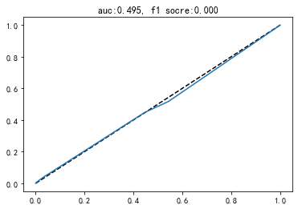

```python
marry = hot_userinfo.loc[:,'婚姻状态_其他情况':'婚姻状态_离异']
x_train,x_test,y_train,y_test = train_test_split(marry,hot_userinfo['逾期'])
predict_overdue(x_train,x_test,y_train,y_test)
```

#### 看看序号：

```
准确率:
 0.7152
参数报告:
               precision    recall  f1-score   support

          逾期       0.00      0.00      0.00       712
         没逾期       0.72      1.00      0.83      1788

    accuracy                           0.72      2500
   macro avg       0.36      0.50      0.42      2500
weighted avg       0.51      0.72      0.60      2500
```

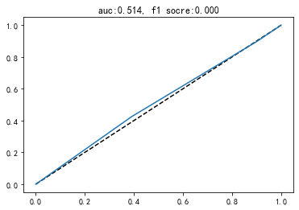

```python
x_train,x_test,y_train,y_test = train_test_split(tab1[['婚姻状态']],tab1['逾期'])
predict_overdue(x_train,x_test,y_train,y_test)
```

### 发现无论特征取何值，无论用哪种编码。该模型均预测为没逾期，这是一个无效的分类器

### 可能原因：①所选特征对目标毫无影响 ② 特征过少

## 2.状态性特征预测

## 所选特征：平均工资，平均非工资，最大工资，最低工资，最大非工资，最低非工资，最大欠款，平均还款

### 2.1 对“分数”做预测：

```python
feat = feature.loc[:,'平均工资收入':'平均还款比例']
target = feature['分数']
x_train,x_test,y_train,y_test = train_test_split(feat,target)
predict_score(x_train,x_test,y_train,y_test)
```

```
普通线性回归的MSE:
 17.010575302124785
梯度下降线性回归的MSE:
 1.532635440866738e+26
岭回归的MSE:
 17.012218843503742
```

### 发现梯度下降线性回归的MSE离大谱，这是因为没有进行无量纲化(最小二乘线性回归即普通线性回归不受影响)

### 所以分别看看标准化和归一化有什么效果：

```python
transfer_standard = StandardScaler()
x_train_standard = transfer_standard.fit_transform(x_train)
x_test_standard = transfer_standard.transform(x_test)
transfer_minMax = MinMaxScaler()
x_train_mm = transfer_minMax.fit_transform(x_train)
x_test_mm = transfer_minMax.transform(x_test)
print("标准化的预测结果:\n")
predict_score(x_train_standard,x_test_standard,y_train,y_test)
print("\n")
print("归一化的预测结果:\n")
predict_score(x_train_mm,x_test_mm,y_train,y_test)
```

```
标准化的预测结果:

普通线性回归的MSE:
 17.01057530212479
梯度下降线性回归的MSE:
 17.425313922667385
岭回归的MSE:
 17.000698194599412


归一化的预测结果:

普通线性回归的MSE:
 17.010575302124764
梯度下降线性回归的MSE:
 17.861041650187918
岭回归的MSE:
 17.003232171345978
```

### 发现 ① 梯度下降线性回归的MSE变正常了 ② 总的来说误差比单特征小了很多

### 2.2 对“逾期”做预测：

```
准确率:
 0.819
参数报告:
               precision    recall  f1-score   support

          逾期       0.79      0.48      0.60       559
         没逾期       0.83      0.95      0.88      1441

    accuracy                           0.82      2000
   macro avg       0.81      0.72      0.74      2000
weighted avg       0.81      0.82      0.80      2000
```

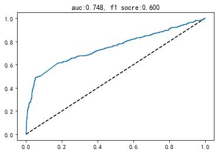

```python
feat = feature.loc[:,'平均工资收入':'平均还款比例']
target = feature['逾期']
x_train,x_test,y_train,y_test = train_test_split(feat,target,test_size=0.2)
predict_overdue(x_train,x_test,y_train,y_test)
```

## 3.趋势性特征预测

## 所选特征：年工资增长趋势，年非工资增长趋势，2157年总工资增长趋势，2157年总非工资增长趋势+最大欠款金额,平均工资收入

```python
feature.head()
```

|  | new_user_id | 逾期 | 分数 | 平均工资收入 | 平均非工资收入 | 最大工资收入 | 最低工资收入 | 最大非工资收入 | 最低非工资收入 | 最大欠款金额 | 平均还款比例 | 年工资增长趋势 | 年非工资增长趋势 | 2157年总工资增长趋势 | 2157年总非工资增长趋势 | 2156年各月支出波动 | 2156年各月收入波动 | 2157年各月收入波动 | 2157年各月支出波动 |
| --- | --- | --- | --- | --- | --- | --- | --- | --- | --- | --- | --- | --- | --- | --- | --- | --- | --- | --- | --- |
| 0 | eddcaa8984f8db5199ec28323efb18a4 | 0 | 80.619639 | 0.0 | 0.000000 | 0.0 | 0.0 | 0.000000 | 0.000000 | 1.516167 | 0.960151 | 0 | 0 | 0 | 0 | 0.000000 | 0.000000 | 0.000000 | 0.000000 |
| 1 | 65b01fba105ee82613babff7c88929c5 | 1 | 53.052357 | 0.0 | 45.383917 | 0.0 | 0.0 | 49.672511 | 30.568844 | 62.891473 | 0.853864 | 0 | 0 | 0 | 0 | 626.641681 | 321.354568 | 206.728575 | 518.877814 |
| 2 | 968083a2d1a7e6b5b85a66b0bc412830 | 1 | 46.796518 | 0.0 | 43.917113 | 0.0 | 0.0 | 48.209510 | 35.416795 | 26.003022 | 0.976416 | 0 | 1 | 0 | 0 | 901.030848 | 151.479003 | 216.189232 | 575.754017 |
| 3 | 18aeed58fd39a58cc1430a3a417ed7a9 | 1 | 82.354501 | 0.0 | 0.000000 | 0.0 | 0.0 | 0.000000 | 0.000000 | 2.374990 | 0.994188 | 0 | 0 | 0 | 0 | 0.000000 | 0.000000 | 0.000000 | 0.000000 |
| 4 | bae4896cea4a34616ae3babca11439ae | 1 | 83.758928 | 0.0 | 0.000000 | 0.0 | 0.0 | 0.000000 | 0.000000 | -47.870395 | -0.809331 | 0 | 0 | 0 | 0 | 0.000000 | 0.000000 | 0.000000 | 0.000000 |

### 3.1 对“分数”做预测:

```python
feat = ['年工资增长趋势','年非工资增长趋势','2157年总工资增长趋势','2157年总非工资增长趋势','最大欠款金额','平均工资收入']
target = feature['分数']
x_train,x_test,y_train,y_test = train_test_split(feature[feat],target)
predict_score(x_train,x_test,y_train,y_test)
```

```
普通线性回归的MSE:
 53.06347339700931
梯度下降线性回归的MSE:
 1.7612775442371368e+25
岭回归的MSE:
 53.058812313089284
```

### 标准化& 归一化:

```python
transfer_standard = StandardScaler()
x_train_standard = transfer_standard.fit_transform(x_train)
x_test_standard = transfer_standard.transform(x_test)
transfer_minMax = MinMaxScaler()
x_train_mm = transfer_minMax.fit_transform(x_train)
x_test_mm = transfer_minMax.transform(x_test)
print("标准化的预测结果:\n")
predict_score(x_train_standard,x_test_standard,y_train,y_test)
print("\n")
print("归一化的预测结果:\n")
predict_score(x_train_mm,x_test_mm,y_train,y_test)
```

```
标准化的预测结果:

普通线性回归的MSE:
 53.06347339700925
梯度下降线性回归的MSE:
 54.614139934096045
岭回归的MSE:
 53.06302952157358


归一化的预测结果:

普通线性回归的MSE:
 53.06347339700931
梯度下降线性回归的MSE:
 53.10415436830241
岭回归的MSE:
 53.056961407609805
```

### 3.2对“逾期”做预测 :

```
准确率:
 0.792
参数报告:
               precision    recall  f1-score   support

          逾期       0.84      0.36      0.51       588
         没逾期       0.79      0.97      0.87      1412

    accuracy                           0.79      2000
   macro avg       0.81      0.67      0.69      2000
weighted avg       0.80      0.79      0.76      2000
```

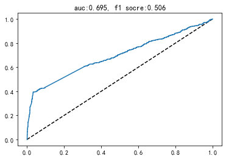

```python
feat = ['年工资增长趋势','年非工资增长趋势','2157年总工资增长趋势','2157年总非工资增长趋势','最大欠款金额','平均工资收入']
target = feature['逾期']
x_train,x_test,y_train,y_test = train_test_split(feature[feat],target,test_size=0.2)
predict_overdue(x_train,x_test,y_train,y_test)
```

### 发现：趋势性特征相比状态性特征表现要差,猜测是因为趋势性特征均为0-1变量,损失了若干有用的信息

## 4.统计量特征预测

## 所选特征：2156年各月支出波动，2156年各月收入波动，2157年各月收入波动，2157年各月支出波动+职业,平均工资收入,平均非工资收入

```python
feat_work = ['new_user_id','职业_事业单位','职业_企业','职业_公职','职业_学生','职业_无业']
feature_plus_work = pd.merge(feature,hot_userinfo.loc[:,feat_work],how='left',on = 'new_user_id')
feature_plus_work.fillna(0,inplace=True)
feature_plus_work.head()
```

|  | new_user_id | 逾期 | 分数 | 平均工资收入 | 平均非工资收入 | 最大工资收入 | 最低工资收入 | 最大非工资收入 | 最低非工资收入 | 最大欠款金额 | ... | 2157年总非工资增长趋势 | 2156年各月支出波动 | 2156年各月收入波动 | 2157年各月收入波动 | 2157年各月支出波动 | 职业_事业单位 | 职业_企业 | 职业_公职 | 职业_学生 | 职业_无业 |
| --- | --- | --- | --- | --- | --- | --- | --- | --- | --- | --- | --- | --- | --- | --- | --- | --- | --- | --- | --- | --- | --- |
| 0 | eddcaa8984f8db5199ec28323efb18a4 | 0 | 80.619639 | 0.0 | 0.000000 | 0.0 | 0.0 | 0.000000 | 0.000000 | 1.516167 | ... | 0 | 0.000000 | 0.000000 | 0.000000 | 0.000000 | 0.0 | 0.0 | 1.0 | 0.0 | 0.0 |
| 1 | 65b01fba105ee82613babff7c88929c5 | 1 | 53.052357 | 0.0 | 45.383917 | 0.0 | 0.0 | 49.672511 | 30.568844 | 62.891473 | ... | 0 | 626.641681 | 321.354568 | 206.728575 | 518.877814 | 1.0 | 0.0 | 0.0 | 0.0 | 0.0 |
| 2 | 968083a2d1a7e6b5b85a66b0bc412830 | 1 | 46.796518 | 0.0 | 43.917113 | 0.0 | 0.0 | 48.209510 | 35.416795 | 26.003022 | ... | 0 | 901.030848 | 151.479003 | 216.189232 | 575.754017 | 0.0 | 0.0 | 1.0 | 0.0 | 0.0 |
| 3 | 18aeed58fd39a58cc1430a3a417ed7a9 | 1 | 82.354501 | 0.0 | 0.000000 | 0.0 | 0.0 | 0.000000 | 0.000000 | 2.374990 | ... | 0 | 0.000000 | 0.000000 | 0.000000 | 0.000000 | 0.0 | 1.0 | 0.0 | 0.0 | 0.0 |
| 4 | bae4896cea4a34616ae3babca11439ae | 1 | 83.758928 | 0.0 | 0.000000 | 0.0 | 0.0 | 0.000000 | 0.000000 | -47.870395 | ... | 0 | 0.000000 | 0.000000 | 0.000000 | 0.000000 | 1.0 | 0.0 | 0.0 | 0.0 | 0.0 |

5 rows × 24 columns

```python
feat = ['平均工资收入','平均非工资收入','职业_事业单位','职业_企业','职业_公职','职业_学生','职业_无业','2156年各月支出波动','2156年各月收入波动','2157年各月收入波动','2157年各月支出波动']
```

### 4.1 对“分数”做预测：

```python
x_train,x_test,y_train,y_test = train_test_split(feature_plus_work[feat],feature_plus_work['分数'])
predict_score(x_train,x_test,y_train,y_test)
```

```
普通线性回归的MSE:
 18.882689668855047
梯度下降线性回归的MSE:
 5.120294152673311e+31
岭回归的MSE:
 18.959229792695957
```

### 归一化：

```python
transfer_minMax = MinMaxScaler()
x_train_mm = transfer_minMax.fit_transform(x_train)
x_test_mm = transfer_minMax.transform(x_test)
print("归一化的预测结果:\n")
predict_score(x_train_mm,x_test_mm,y_train,y_test)
```

```
归一化的预测结果:

普通线性回归的MSE:
 18.882689668855107
梯度下降线性回归的MSE:
 19.67234913050887
岭回归的MSE:
 18.954785937846342
```

### 4.2 对“逾期”做预测:

```
准确率:
 0.805
参数报告:
               precision    recall  f1-score   support

          逾期       0.79      0.46      0.58       587
         没逾期       0.81      0.95      0.87      1413

    accuracy                           0.81      2000
   macro avg       0.80      0.70      0.73      2000
weighted avg       0.80      0.81      0.79      2000
```

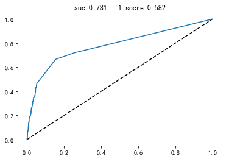

```python
x_train,x_test,y_train,y_test = train_test_split(feature_plus_work[feat],feature_plus_work['逾期'],test_size=0.2)
predict_overdue(x_train,x_test,y_train,y_test)
```